# PCA

[Home](https://teri2023.github.io/index.html)|

|

Principal Component Analysis

# **DATASET**:

```python
import pandas as pd
	import numpy as np
	import matplotlib.pyplot as plt
	import seaborn as sb
	from sklearn.utils.extmath import svd_flip
```

```python
#load the data set and read by panda
	url = "https://archive.ics.uci.edu/ml/machine-learning-databases/iris/iris.data"
	df = pd.read_csv(url, names=['sepal length','sepal width','petal length','petal width','target'])
	df.head()
```

|  | sepal length | sepal width | petal length | petal width | target |
| --- | --- | --- | --- | --- | --- |
| 0 | 5.1 | 3.5 | 1.4 | 0.2 | Iris-setosa |
| 1 | 4.9 | 3.0 | 1.4 | 0.2 | Iris-setosa |
| 2 | 4.7 | 3.2 | 1.3 | 0.2 | Iris-setosa |
| 3 | 4.6 | 3.1 | 1.5 | 0.2 | Iris-setosa |
| 4 | 5.0 | 3.6 | 1.4 | 0.2 | Iris-setosa |

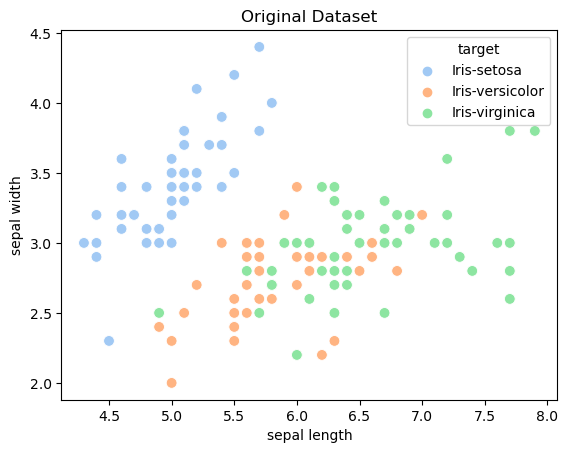

```python
# plot scatter plot between sepal length and sepal width
	sb.scatterplot(data = df , x = 'sepal length',y = 'sepal width' , hue = 'target' , s = 60 , palette= 'pastel')
	plt.title("Original Dataset")
```

```python
# pick first 4 columns and drop another columns
	data = df.iloc[:,0:4]
	print(data.head())
```

```
   sepal length  sepal width  petal length  petal width
	0           5.1          3.5           1.4          0.2
	1           4.9          3.0           1.4          0.2
	2           4.7          3.2           1.3          0.2
	3           4.6          3.1           1.5          0.2
	4           5.0          3.6           1.4          0.2
```

# **FIND X_MEAN**:

```python
# convert dataframe to list of numpy
	X = data.to_numpy()
	print(X.shape)
	print (X[0:5])
```

```
(150, 4)
	[[5.1 3.5 1.4 0.2]
	 [4.9 3.  1.4 0.2]
	 [4.7 3.2 1.3 0.2]
	 [4.6 3.1 1.5 0.2]
	 [5.  3.6 1.4 0.2]]
```

```python
# centerlize dataset with mean
	X_meaned = X - np.mean(X , axis = 0)
	print(np.mean(X , axis = 0))
	print(X_meaned.shape)
	print(X_meaned [0:5])
```

```
[5.84333333 3.054      3.75866667 1.19866667]
	(150, 4)
	[[-0.74333333  0.446      -2.35866667 -0.99866667]
	 [-0.94333333 -0.054      -2.35866667 -0.99866667]
	 [-1.14333333  0.146      -2.45866667 -0.99866667]
	 [-1.24333333  0.046      -2.25866667 -0.99866667]
	 [-0.84333333  0.546      -2.35866667 -0.99866667]]
```

# **PCA**:

# **What is PCA**:

The concept of Principal Component Analysis (PCA) was introduced by mathematician Karl Pearson in 1901, who is considered one of the founders of mathematical statistics. PCA has since become a standard tool in data analysis for reducing complex data sets to simpler forms and extracting underlying meanings. According to Johnathan, PCA effectively simplifies complex data sets and reveals hidden patterns. In the original data set scatter plot below, data points are mixed, leading to high error bars in linear regression predictions. However, the original PCA scatter plot below, with its distinct blue, orange, and green data sets, shows clearer separation and condensation of data points. This reduction in redundancy allows for more accurate trend predictions and the creation of reliable prediction models.

# **How PCA work**:

Step 1: We start with the X matrix, which has m rows and n columns. The first step is to remove any empty or "zero" values by subtracting the mean of each value in X. This normalization step ensures that our data is centered around the origin.

Step 4: Finally, we compute the PCA transformation. This is done by multiplying the original X matrix by the eigenvector matrix V. The resulting matrix, X_pca, represents our data in the new principal component space.

These steps transform the original data set into a simpler form, highlighting the most important patterns and relationships between variables.

**Step 1: covariance**

```python
# find covariance matrix
	n_sa, n_fe = X_meaned.shape
	C = (X_meaned.T @ X_meaned) / (n_sa-1)
	print(X_meaned.T.shape)
	print(X_meaned[0:5].T)
	print(n_sa-1)
	print(C.shape)
	print(C)
```

```
(4, 150)
	[[-0.74333333 -0.94333333 -1.14333333 -1.24333333 -0.84333333]
	 [ 0.446      -0.054       0.146       0.046       0.546     ]
	 [-2.35866667 -2.35866667 -2.45866667 -2.25866667 -2.35866667]
	 [-0.99866667 -0.99866667 -0.99866667 -0.99866667 -0.99866667]]
	149
	(4, 4)
	[[ 0.68569351 -0.03926846  1.27368233  0.5169038 ]
	 [-0.03926846  0.18800403 -0.32171275 -0.11798121]
	 [ 1.27368233 -0.32171275  3.11317942  1.29638747]
	 [ 0.5169038  -0.11798121  1.29638747  0.58241432]]
```

**Step 2: EIGENVECTOR**

```python
#step 1: find eigen_values, eigen_vectors for C
	w, v = np.linalg.eig(C)
	print(w.shape)
	print(w)
	print(v.shape)
	print(v)
```

```
(4,)
	[4.22484077 0.24224357 0.07852391 0.02368303]
	(4, 4)
	[[ 0.36158968 -0.65653988 -0.58099728  0.31725455]
	 [-0.08226889 -0.72971237  0.59641809 -0.32409435]
	 [ 0.85657211  0.1757674   0.07252408 -0.47971899]
	 [ 0.35884393  0.07470647  0.54906091  0.75112056]]
```

```python
# step 2: dot X with eigen _vetor
	X_trans = X @ v
	print(X_trans.shape)
	print(X_trans[0:5])
```

```
(150, 4)
	[[ 2.82713597 -5.64133105 -0.66427693 -0.03771451]
	 [ 2.79595248 -5.14516688 -0.84628652  0.06088175]
	 [ 2.62152356 -5.17737812 -0.61805585 -0.01941613]
	 [ 2.7649059  -5.00359942 -0.60509312 -0.11467594]
	 [ 2.78275012 -5.64864829 -0.54653539 -0.1018494 ]]
```

```python
# step 3: reduce Matrix by component #
	n_components = 2
	X_trans = X_trans[:, :n_components]
	print(X_trans.shape)
	print(X_trans[0:5])
```

```
(150, 2)
	[[ 2.82713597 -5.64133105]
	 [ 2.79595248 -5.14516688]
	 [ 2.62152356 -5.17737812]
	 [ 2.7649059  -5.00359942]
	 [ 2.78275012 -5.64864829]]
```

**Step 3: plotting**

```python
target = df.iloc[:,4]
	principal_df = pd.DataFrame(X_trans, columns = ['PC1', 'PC2'])
	principal_df = pd.concat([principal_df , pd.DataFrame(target)] , axis = 1)
	principal_df.head()
```

|  | PC1 | PC2 | target |
| --- | --- | --- | --- |
| 0 | 2.827136 | -5.641331 | Iris-setosa |
| 1 | 2.795952 | -5.145167 | Iris-setosa |
| 2 | 2.621524 | -5.177378 | Iris-setosa |
| 3 | 2.764906 | -5.003599 | Iris-setosa |
| 4 | 2.782750 | -5.648648 | Iris-setosa |

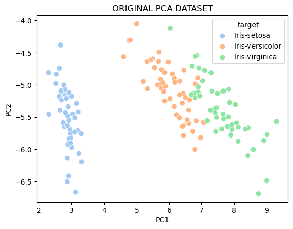

```python
sb.scatterplot(data = principal_df , x = 'PC1',y = 'PC2' , hue = 'target' , s = 60 , palette= 'pastel')
	plt.title("ORIGINAL PCA DATASET")
```

The scatter plot indicates the results of Principal Component Analysis (PCA) on the Iris dataset. The plot shows data points along two principal components: PC1 (X-axis) and PC2 (Y-axis). The data points are color-coded according to the three Iris species: blue for Iris-setosa, orange for Iris-versicolor, and green for Iris-virginica. The X-axis, labeled PC1, ranges from 2 to 9, while the Y-axis, labeled PC2, ranges from -7 to -4. The plot reveals distinct clusters for each species, with Iris-setosa forming a well-separated group on the left, Iris-versicolor in the middle, and Iris-virginica on the right. This PCA transformation highlights the separability of the species in a reduced dimensional space, making it easier to distinguish between them based on the principal components.

# **SVD**:

# **What is SVD**:

Singular Value Decomposition (SVD) was discovered before Principal Component Analysis (PCA) and developed by multiple mathematicians over time. It was first identified by Eugenio Beltrami in 1873 and further refined through the 20th century, with significant advancements made using the Jacobi eigenvalue algorithm in 1958 and Kahan's algorithm in 1970. SVD is simpler than PCA and is widely used by data scientists to analyze complex, unstructured data sets by reducing large matrices into smaller, compact forms with high redundancy. When comparing the same dataset used for PCA, the SVD-transformed graph shows similar clustering and separation of data points, maintaining their positions and integrity while offering a more condensed representation. This makes SVD a valuable tool for data reduction and pattern recognition.

# **How SVD work**:

Singular Value Decomposition (SVD) starts similarly to Principal Component Analysis (PCA) by normalizing the original matrix to remove zero values. The next step involves finding orthonormal sets U and V, which serve as matrix components. This process is similar to calculating vector components through orthogonal projection, where U and V represent the components of the original matrix. U is sized according to the original matrix, while V is a square matrix based on the number of columns. The third step involves calculating Sigma, which represents the variances within U and V. Finally, the main SVD formula is applied to decompose the matrix. Unlike PCA, which identifies relationships across the entire matrix, SVD focuses on the relationships between individual elements within the matrix, providing detailed insights into the data's structure.

**Step 1: Find U, Total and Vt**

```python
U, S, Vt = np.linalg.svd(X_meaned, full_matrices=False)
	print(U.shape)
	print(U[0:5])
	print(S)
	print(Vt.shape)
	print(Vt[0:5])
```

```
(150, 4)
	[[-0.10698373 -0.0543634   0.00628903  0.00053562]
	 [-0.1082266   0.02822254  0.05949987  0.05302225]
	 [-0.11517876  0.02286102 -0.00722379  0.01027656]
	 [-0.10946401  0.05178628 -0.01101347 -0.04043395]
	 [-0.1087528  -0.05558135 -0.02813294 -0.03360588]]
	[25.08986398  6.00785254  3.42053538  1.87850234]
	(4, 4)
	[[ 0.36158968 -0.08226889  0.85657211  0.35884393]
	 [-0.65653988 -0.72971237  0.1757674   0.07470647]
	 [ 0.58099728 -0.59641809 -0.07252408 -0.54906091]
	 [ 0.31725455 -0.32409435 -0.47971899  0.75112056]]
```

**Step 2: Transport**

```python
# flip eigenvectors' sign to enforce deterministic output
	U, Vt = svd_flip(U, Vt)
	print(U.shape)
	print(U[0:5])
	print(Vt.shape)
	print(Vt[0:5])
```

```
(150, 4)
	[[-0.10698373  0.0543634  -0.00628903  0.00053562]
	 [-0.1082266  -0.02822254 -0.05949987  0.05302225]
	 [-0.11517876 -0.02286102  0.00722379  0.01027656]
	 [-0.10946401 -0.05178628  0.01101347 -0.04043395]
	 [-0.1087528   0.05558135  0.02813294 -0.03360588]]
	(4, 4)
	[[ 0.36158968 -0.08226889  0.85657211  0.35884393]
	 [ 0.65653988  0.72971237 -0.1757674  -0.07470647]
	 [-0.58099728  0.59641809  0.07252408  0.54906091]
	 [ 0.31725455 -0.32409435 -0.47971899  0.75112056]]
```

**Step 3: plotting**

```python
X_trans_SVD_full = U * S
	X_trans_SVD = U[:, :n_components] * S[:n_components]
	print(X_trans_SVD_full[0:5])
	print(X_trans_SVD.shape)
	print(X_trans_SVD[0:5])
```

```
[[-2.68420713e+00  3.26607315e-01 -2.15118370e-02  1.00615724e-03]
	 [-2.71539062e+00 -1.69556848e-01 -2.03521425e-01  9.96024240e-02]
	 [-2.88981954e+00 -1.37345610e-01  2.47092410e-02  1.93045428e-02]
	 [-2.74643720e+00 -3.11124316e-01  3.76719753e-02 -7.59552741e-02]
	 [-2.72859298e+00  3.33924564e-01  9.62296998e-02 -6.31287327e-02]]
	(150, 2)
	[[-2.68420713  0.32660731]
	 [-2.71539062 -0.16955685]
	 [-2.88981954 -0.13734561]
	 [-2.7464372  -0.31112432]
	 [-2.72859298  0.33392456]]
```

```python
target = df.iloc[:,4]
	principal_df = pd.DataFrame(X_trans_SVD, columns = ['PC1', 'PC2'])
	principal_df = pd.concat([principal_df , pd.DataFrame(target)] , axis = 1)
	principal_df.head()
```

|  | PC1 | PC2 | target |
| --- | --- | --- | --- |
| 0 | -2.684207 | 0.326607 | Iris-setosa |
| 1 | -2.715391 | -0.169557 | Iris-setosa |
| 2 | -2.889820 | -0.137346 | Iris-setosa |
| 3 | -2.746437 | -0.311124 | Iris-setosa |
| 4 | -2.728593 | 0.333925 | Iris-setosa |

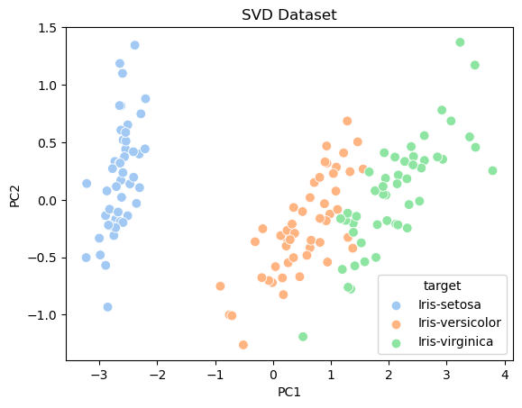

```python
sb.scatterplot(data = principal_df , x = 'PC1',y = 'PC2' , hue = 'target' , s = 60 , palette= 'pastel')
	plt.title("SVD Dataset")
```

The scatter plot indicates the results of Singular Value Decomposition (SVD) applied to the Iris dataset. The plot features two principal components: PC1 (X-axis) and PC2 (Y-axis). Data points are color-coded according to the three Iris species: blue for Iris-setosa, orange for Iris-versicolor, and green for Iris-virginica. The X-axis, labeled PC1, ranges from -3 to 4, while the Y-axis, labeled PC2, ranges from -1.5 to 1.5. The plot reveals distinct clusters for each species, with Iris-setosa forming a well-separated group on the left, Iris-versicolor in the middle, and Iris-virginica on the right. This SVD transformation emphasizes the separability of the species in the reduced dimensional space, making it easier to distinguish between them based on the principal components.